# Traffic_Sign_Classifier_final

## Project: Build a Traffic Sign Recognition Classifier

In this notebook, a template is provided for you to implement your functionality in stages which is required to successfully complete this project. If additional code is required that cannot be included in the notebook, be sure that the Python code is successfully imported and included in your submission, if necessary. Sections that begin with **'Implementation'** in the header indicate where you should begin your implementation for your project. Note that some sections of implementation are optional, and will be marked with **'Optional'** in the header.

In addition to implementing code, there will be questions that you must answer which relate to the project and your implementation. Each section where you will answer a question is preceded by a **'Question'** header. Carefully read each question and provide thorough answers in the following text boxes that begin with **'Answer:'**. Your project submission will be evaluated based on your answers to each of the questions and the implementation you provide.

## Step 0: Load The Data

```python
# Load pickled data
import pickle

# Load the training and testing data
training_file = "traffic-signs-data/train.p"
testing_file = "traffic-signs-data/test.p"

with open(training_file, mode='rb') as f:
    train = pickle.load(f)
with open(testing_file, mode='rb') as f:
    test = pickle.load(f)

X_train, y_train = train['features'], train['labels']
X_test, y_test = test['features'], test['labels']

del training_file, testing_file, train, test
```

## Step 1: Dataset Summary & Exploration

The pickled data is a dictionary with 4 key/value pairs:

- `'features'` is a 4D array containing raw pixel data of the traffic sign images, (num examples, width, height, channels).
- `'labels'` is a 2D array containing the label/class id of the traffic sign. The file `signnames.csv` contains id -> name mappings for each id.
- `'sizes'` is a list containing tuples, (width, height) representing the the original width and height the image.
- `'coords'` is a list containing tuples, (x1, y1, x2, y2) representing coordinates of a bounding box around the sign in the image. **THESE COORDINATES ASSUME THE ORIGINAL IMAGE. THE PICKLED DATA CONTAINS RESIZED VERSIONS (32 by 32) OF THESE IMAGES**

```python
import numpy as np

# Number of training examples
n_train = len(X_train)

# Number of testing examples
n_test = len(X_test)

# What's the shape of an traffic sign image?
image_shape = X_train[0].shape

# How many unique classes/labels there are in the dataset?
n_classes = len(np.unique(y_train))

print("Number of training examples =", n_train)
print("Number of testing examples =", n_test)
print("Image data shape =", image_shape)
print("Number of classes =", n_classes)

del n_train, n_test, image_shape, n_classes
```

```
Number of training examples = 39209
Number of testing examples = 12630
Image data shape = (32, 32, 3)
Number of classes = 43
```

Visualize the German Traffic Signs Dataset using the pickled file(s). This is open ended, suggestions include: plotting traffic sign images, plotting the count of each sign, etc.

The [Matplotlib](http://matplotlib.org/) [examples](http://matplotlib.org/examples/index.html) and [gallery](http://matplotlib.org/gallery.html) pages are a great resource for doing visualizations in Python.

[figure not shown]

```python
import random
import matplotlib.pyplot as plt
%matplotlib inline

# Create a dictionary to hold sample size for each label
count_of_labels = {}
y_list = y_train.tolist()

# Loop through labels to count distinct signs and plot one sample for each
for i in np.unique(y_train):
    count_of_labels[i] = y_list.count(i)
    for n in range(len(y_train)):
        if y_train[n] == i:
            plt.subplot(5, 10, i+1)
            plt.imshow(X_train[n], cmap="gray")
            plt.axis('off')
            plt.title(y_train[n])
            break

del y_list
```

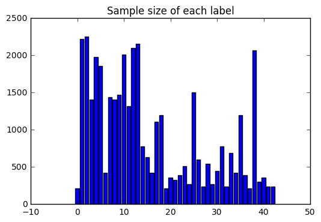

```
{0: 210, 1: 2220, 2: 2250, 3: 1410, 4: 1980, 5: 1860, 6: 420, 7: 1440, 8: 1410, 9: 1470, 10: 2010, 11: 1320, 12: 2100, 13: 2160, 14: 780, 15: 630, 16: 420, 17: 1110, 18: 1200, 19: 210, 20: 360, 21: 330, 22: 390, 23: 510, 24: 270, 25: 1500, 26: 600, 27: 240, 28: 540, 29: 270, 30: 450, 31: 780, 32: 24…
```

```python
# Plot sample size of each label in the training set
plt.bar(range(len(count_of_labels)), count_of_labels.values(), align='center')
plt.title("Sample size of each label")
plt.show()
print (count_of_labels)
```

## Step 2: Design and Test a Model Architecture

Design and implement a deep learning model that learns to recognize traffic signs. Train and test your model on the [German Traffic Sign Dataset](http://benchmark.ini.rub.de/?section=gtsrb&subsection=dataset).

There are various aspects to consider when thinking about this problem:

- Neural network architecture
- Play around preprocessing techniques (normalization, rgb to grayscale, etc)
- Number of examples per label (some have more than others).
- Generate fake data.

Here is an example of a [published baseline model on this problem](http://yann.lecun.com/exdb/publis/pdf/sermanet-ijcnn-11.pdf). It's not required to be familiar with the approach used in the paper but, it's good practice to try to read papers like these.

### Implementation

Use the code cell (or multiple code cells, if necessary) to implement the first step of your project. Once you have completed your implementation and are satisfied with the results, be sure to thoroughly answer the questions that follow.

```python
import tensorflow as tf
from sklearn.utils import shuffle
from scipy import ndimage
from random import randint

### Features and labels
x = tf.placeholder(tf.float32, (None, 32, 32, 3))
y = tf.placeholder(tf.int32, (None))
one_hot_y = tf.one_hot(y, 43)
```

```python
### Preprocessing data
# Balance out number of examples per label
X_train_extra = X_train
y_train_extra = y_train

for i in count_of_labels:
    # Ensure minimum 2000 examples per label
    if count_of_labels[i] < 2000:
        missing = 2000 - count_of_labels[i]

        sample = X_train[np.where(y_train == i)]
        X_new = []
        y_new = []

        for n in range (missing):
            index = randint(0, len(sample)-1)
            angle = randint(-30, 30)
            X_new.append(ndimage.rotate(sample[index], angle, reshape=False))
            y_new.append(i)

        X_train_extra = np.append(X_train_extra, X_new, axis=0)
        y_train_extra = np.append(y_train_extra, y_new, axis=0)

# Normalize to 0.1 - 0.9
X_train_normalize_extra = X_train_extra / 255 * 0.8 + 0.1

# Check ranges
print(X_train_extra.min(), X_train_extra.max(), X_train_normalize_extra.min(), X_train_normalize_extra.max())

# Split training set to train and validation sets
from sklearn.cross_validation import train_test_split

X_train, X_validation, y_train, y_validation = train_test_split(X_train_normalize_extra, y_train_extra,
                                                                test_size=0.20, random_state=1000)

del missing, sample, X_new, y_new, index, angle, X_train_extra, X_train_normalize_extra, y_train_extra
```

```
0 255 0.1 0.9
```

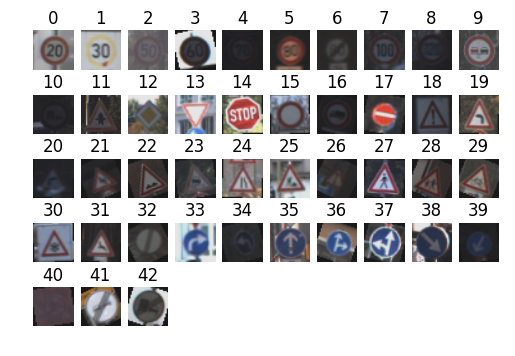

```python
### Visualize processed data
# Create a dictionary to hold sample size for each label
count_of_labels_extra = {}
y_list = y_train.tolist()

# Loop through labels to count distinct signs and plot one sample for each
for i in np.unique(y_train):
    count_of_labels_extra[i] = y_list.count(i)
    for n in range(len(y_train)):
        if y_train[n] == i:
            plt.subplot(5, 10, i+1)
            plt.imshow(X_train[n], cmap="gray")
            plt.axis('off')
            plt.title(y_train[n])
            break

del y_list
```

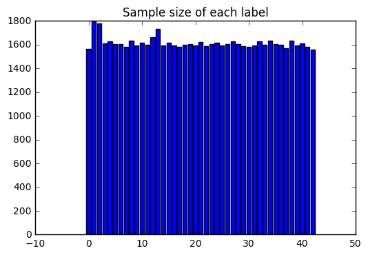

```
{0: 1565, 1: 1800, 2: 1779, 3: 1610, 4: 1627, 5: 1605, 6: 1604, 7: 1582, 8: 1635, 9: 1596, 10: 1618, 11: 1598, 12: 1661, 13: 1732, 14: 1592, 15: 1614, 16: 1592, 17: 1582, 18: 1597, 19: 1603, 20: 1594, 21: 1620, 22: 1587, 23: 1603, 24: 1619, 25: 1596, 26: 1605, 27: 1631, 28: 1608, 29: 1590, 30: 1583,…
```

```python
# Plot sample size of each label in the training set
plt.bar(range(len(count_of_labels_extra)), count_of_labels_extra.values(), align='center')
plt.title("Sample size of each label")
plt.show()
print (count_of_labels_extra)

del count_of_labels, count_of_labels_extra
```

#### Testing process

```python
### Hyperparameters
EPOCHS = 25
BATCH_SIZE = 32
mu = 0
sigma = 0.1
strides = 1
k = 2
rate = 0.001
```

```python
### Implement LeNet-5
from tensorflow.contrib.layers import flatten

# Conv2D wrapper, with bias and relu activation
def conv2d(x, W, b, strides):
    x = tf.nn.conv2d(x, W, strides=[1, strides, strides, 1], padding='VALID')
    x = tf.nn.bias_add(x, b)
    return tf.nn.relu(x)

# Max-pooling
def maxpool2d(x, k):
    return tf.nn.max_pool(x, ksize=[1, k, k, 1], strides=[1, k, k, 1], padding='VALID')

def LeNet(x):
    # Layer 1
    conv1 = conv2d(x, tf.Variable(tf.truncated_normal(shape=(5, 5, 3, 6), mean = mu, stddev = sigma)),
                   tf.Variable(tf.zeros(6)), strides)
    conv1 = maxpool2d(conv1, k)

    # Layer 2
    conv2 = conv2d(conv1, tf.Variable(tf.truncated_normal(shape=(5, 5, 6, 16), mean = mu, stddev = sigma)),
                   tf.Variable(tf.zeros(16)), strides)
    conv2 = maxpool2d(conv2, k)

    # Fully connected layer
    # Reshape conv3 output to fit fully connected layer input
    fc11 = flatten(conv2)
    fc11 = tf.add(tf.matmul(fc11, tf.Variable(tf.truncated_normal(shape=(400, 120), mean = mu, stddev = sigma))),
                            tf.Variable(tf.zeros(120)))
    fc11 = tf.nn.relu(fc11)

    # Fully connected layer
    fc12 = tf.add(tf.matmul(fc11, tf.Variable(tf.truncated_normal(shape=(120, 84), mean = mu, stddev = sigma))),
                            tf.Variable(tf.zeros(84)))
    fc12 = tf.nn.relu(fc12)

    # Output Layer - class prediction
    out = tf.add(tf.matmul(fc12, tf.Variable(tf.truncated_normal(shape=(84, 43), mean = mu, stddev = sigma))),
                           tf.Variable(tf.zeros(43)))
    return out
```

```
Model saved
```

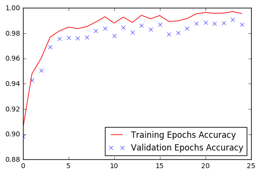

```
[0.90433129823753022, 0.94798986291901854, 0.96011404216104135, 0.97710517221518256, 0.98184252966248131, 0.98490957262988132, 0.98370003455823063, 0.9852551549360673, 0.98897016472756594, 0.9931459509273125, 0.98806301117382789, 0.99281476788388434, 0.98861018315862226, 0.99426909342241676, 0.99147…
```

```python
### Train the Model - LeNet
# Training Pipeline
logits = LeNet(x)
cross_entropy = tf.nn.softmax_cross_entropy_with_logits(logits, one_hot_y)
loss_operation = tf.reduce_mean(cross_entropy)
optimizer = tf.train.AdamOptimizer(learning_rate = rate)
training_operation = optimizer.minimize(loss_operation)

# Model Evaluation
correct_prediction = tf.equal(tf.argmax(logits, 1), tf.argmax(one_hot_y, 1))
accuracy_operation = tf.reduce_mean(tf.cast(correct_prediction, tf.float32))
saver = tf.train.Saver()

# Model Evaluation
def evaluate(X_data, y_data):
    num_examples = len(X_data)
    total_accuracy = 0
    sess = tf.get_default_session()
    for offset in range(0, num_examples, BATCH_SIZE):
        batch_x, batch_y = X_data[offset:offset+BATCH_SIZE], y_data[offset:offset+BATCH_SIZE]
        accuracy = sess.run(accuracy_operation, feed_dict={x: batch_x, y: batch_y})
        total_accuracy += (accuracy * len(batch_x))
    return total_accuracy / num_examples

with tf.Session() as sess:
    sess.run(tf.global_variables_initializer())
    num_examples = len(X_train)
    train_accuracy = []
    validation_accuracy = []

    for i in range(EPOCHS):
        X_data, y_data = shuffle(X_train, y_train)
#        log_start = 0
#        train_accuracy_batch = []
#        validation_accuracy_batch = []
        for offset in range(0, num_examples, BATCH_SIZE):
            end = offset + BATCH_SIZE
            batch_x, batch_y = X_data[offset:end], y_data[offset:end]
            sess.run(training_operation, feed_dict={x: batch_x, y: batch_y})

#            if log_start < 100: # log 100 batches
#                train_accuracy_batch.append(evaluate(batch_x, batch_y))

#                index = randint(0, int(len(y_validation)-1-BATCH_SIZE*0.2))
#                end = index+int(BATCH_SIZE*0.2)
#                validation_accuracy_batch.append(evaluate(X_validation_normalize[index:end], y_validation[index:end]))

#                log_start += 1

        train_accuracy.append(evaluate(X_train, y_train))
        validation_accuracy.append(evaluate(X_validation, y_validation))

#        plt.plot(range(log_start), train_accuracy_batch, 'r--', label='Training Accuracy')
#        plt.plot(range(log_start), validation_accuracy_batch, 'r', label='Validation Accuracy')
#        plt.legend(loc=4)
#        plt.show()

    saver.save(sess, 'Traffic_Sign_Classifier_final')
    print("Model saved")

    plt.plot(range(EPOCHS), train_accuracy, 'r', label='Training Epochs Accuracy')
    plt.plot(range(EPOCHS), validation_accuracy, 'x', label='Validation Epochs Accuracy')
    plt.legend(loc=4)
    plt.show()
    print (train_accuracy, validation_accuracy)
```

```python
### Evaluate the Model
# Normalize test set
X_test_normalize = X_test/ 255 * 0.8 + 0.1

with tf.Session() as sess:
    saver.restore(sess, tf.train.latest_checkpoint('.'))

    test_accuracy = evaluate(X_test_normalize, y_test)
    print("Test Accuracy = {:.3f}".format(test_accuracy))
```

```
Test Accuracy = 0.927
```

### Question 1

*Describe how you preprocessed the data. Why did you choose that technique?*

**Answer:**

1. Generate new images by rotating existing examples to balance out the number of examples (minimum 2000) per label.
2. Normalize train and validation to adjust for different brightness in the images.
3. Split training set 80/20 to train and validation sets.
4. Test original, normalized, original_extra and normalized_extra data using similar set-up in LeNet Lab:
   - the accuracy is around 0.96 for all with normalized_extra being the highest
   - normalized_extra also seem to learn faster in early epochs
   - select normalized_extra for training and delete others

### Question 2

*Describe how you set up the training, validation and testing data for your model. **Optional**: If you generated additional data, how did you generate the data? Why did you generate the data? What are the differences in the new dataset (with generated data) from the original dataset?*

**Answer:**

Describe how you set up the training, validation and testing data for your model:

- testing data is loaded from original test file. This is not used until the end and it's only used once.
- original train file is split 80/20 to create training and validation sets.

how did you generate the data?

Why did you generate the data?

- the number of examples per label is not balanced
- it may cause the model to focus too much on the ones with more examples

What are the differences in the new dataset (with generated data) from the original dataset?

### Question 3

*What does your final architecture look like? (Type of model, layers, sizes, connectivity, etc.) For reference on how to build a deep neural network using TensorFlow, see Deep Neural Network in TensorFlow from the classroom.*

**Answer:**

Since LeNet inplementation worked well to begin with, I kept its architecture:

- Convolution layer 1: use (5, 5, 3, 6) filter with 1 stride, the output shape is 28x28x6.
- Activation 1: use ReLU activation.
- Pooling layer 1: use max pooling with ksize and stides equal to 2, the output shape is 14x14x6.
- Convolution layer 2. use (5, 5, 6, 16) filter with 1 stride, the output shape is 10x10x16.
- Activation 2: use ReLU activation.
- Pooling layer 2: use max pooling with ksize and stides equal to 2, the output shape is 5x5x16.
- Flatten layer: flatten the output shape of the final pooling layer such that it's 1D instead of 3D.
- Fully connected layer 1: it has 120 outputs.
- Activation 3: use ReLU activation.
- Fully connected layer 2: it has 84 outputs.
- Activation 4: use ReLU activation.
- Fully connected layer 3: this is the output layer. It has 43 outputs.

### Question 4

*How did you train your model? (Type of optimizer, batch size, epochs, hyperparameters, etc.)*

**Answer:**

My testing process is guided by this paper: https://arxiv.org/pdf/1412.6980v8.pdf

- Optimizer: Adam optimizer
  - Adam optimizer uses moving averages of the parameters, it generally performs better than the Gradient Decent Optimizer. Test confirms this.
- Learning rate: 0.001
  - Paper suggested Adam optimizer works better with smaller learning rate. I tested few values range(0.001 - 0.01).
- Batch size: 32
  - Larger batch size yield faster computation but worse performance (since epochs was fixed). Tested 10, 32(default suggested by the paper), 100, 500, 1000 and choose 32.
  - By-batch learning process was plotted and observed to help with the testing
- EPOCHS: 25
  - Started with 50, algorithm learns very fast after just a few epochs, so 25 is selected.

Since these parameters have implication on each other, several combinations were tested before choosing the final set.

- Other parameters: mu = 0, sigma = 0.1, strides = 1, k = 2
  - Did not change given the initial setting, achieved high accuracy.

### Question 5

*What approach did you take in coming up with a solution to this problem? It may have been a process of trial and error, in which case, outline the steps you took to get to the final solution and why you chose those steps. Perhaps your solution involved an already well known implementation or architecture. In this case, discuss why you think this is suitable for the current problem.*

**Answer:**

1. Explore the original data and split training to train and validation
   - train set has uneven number of examplers per label: generated extra images to balance it out
   - images have different brightness: create a normalized version of data
1. Test original, normalized, original_extra and normalized_extra data using similar set-up in LeNet Lab
   - based on accuracy and speed to accuracy, normalized_extra data is choosen for further testing
1. Given that the accuracy is already high, test epochs, batch size and learning rate using LeNet Lab set-up
   - testing process described in Question 4 Answer
1. Score test data

## Step 3: Test a Model on New Images

Take several pictures of traffic signs that you find on the web or around you (at least five), and run them through your classifier on your computer to produce example results. The classifier might not recognize some local signs but it could prove interesting nonetheless.

You may find `signnames.csv` useful as it contains mappings from the class id (integer) to the actual sign name.

### Implementation

Use the code cell (or multiple code cells, if necessary) to implement the first step of your project. Once you have completed your implementation and are satisfied with the results, be sure to thoroughly answer the questions that follow.

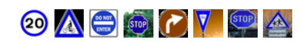

```python
### Load the images and plot them
import cv2

# Downloaded 6 images and converted them to 32x32 online
myimage = ['20.png', 'bike.png', 'DoNotEnter.png', 'Stop.png',
           'TurnRight.png', 'yield.png', 'Stop2.png', 'Children.png']
    # Output label should be 0, 29, ??, 14, 33, 13, 14, 28

myimage_test = []

for image in myimage:
    img = cv2.imread('test_images/' + image, 1)
    img_normalize = img / 255 * 0.8 + 0.1
    myimage_test.append(img_normalize)
    plt.subplot(1, 8, len(myimage_test))
    plt.imshow(img, cmap="gray")
    plt.axis('off')
```

```python
# Just checking
print(len(myimage_test))
print(myimage_test[0].shape)
print(myimage_test[0].min(), myimage_test[0].max())
arr = np.array(myimage_test)
print(arr.shape)
```

```
8
(32, 32, 3)
0.1 0.9
(8, 32, 32, 3)
```

### Question 6

*Choose five candidate images of traffic signs and provide them in the report. Are there any particular qualities of the image(s) that might make classification difficult? It could be helpful to plot the images in the notebook.*

**Answer:**

The training dataset is German Traffic Signs, but the images I gathered here for testing are not. Some of the shape, color or the signs themselves are unseen by the training set. Other factors including brightness, contrast and angle may also be contributing to the prediction errors.

*I think the color made it difficult. I tried several adjustments, e.g. cv2.COLOR_BGR2RGB, but it doesn't restore the original color. Actually, it flips the image color completely for some reason.

```python
# Run the prediction

with tf.Session() as sess:
    saver.restore(sess, tf.train.latest_checkpoint('.'))
    output = sess.run(tf.argmax(logits, 1), feed_dict={x: myimage_test})
    print (output)
```

```
[18 24 38 38 13 30 40 38]
```

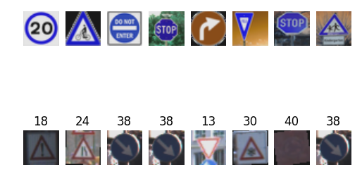

```python
# Plot an example of output
for i in range(len(output)):
    plt.subplot(2, 8, i+1)
    plt.imshow(myimage_test[i], cmap="gray")
    plt.axis('off')

for i in range(len(output)):
    for n in range(len(y_train)):
        if y_train[n] == output[i]:
            plt.subplot(2, 8, i+9)
            plt.imshow(X_train[n], cmap="gray")
            plt.axis('off')
            plt.title(y_train[n])
            break
```

### Question 7

*Is your model able to perform equally well on captured pictures when compared to testing on the dataset? The simplest way to do this check the accuracy of the predictions. For example, if the model predicted 1 out of 5 signs correctly, it's 20% accurate.*

**NOTE:** You could check the accuracy manually by using `signnames.csv` (same directory). This file has a mapping from the class id (0-42) to the corresponding sign name. So, you could take the class id the model outputs, lookup the name in `signnames.csv` and see if it matches the sign from the image.

**Answer:**

Although the accuracy on the test set (from German Traffic Signs) was .927, the model could not predict the new images correctly, the accuracy became 0% (see comparison in the plot above: actual vs predicted). As a result, I believe my model is not generalized well in the real world situation. To develop a model that would perform well, more traffic sign data in a varity of environment and situations will likely be needed.

### Question 8

*Use the model's softmax probabilities to visualize the **certainty** of its predictions, [`tf.nn.top_k`](https://www.tensorflow.org/versions/r0.12/api_docs/python/nn.html#top_k) could prove helpful here. Which predictions is the model certain of? Uncertain? If the model was incorrect in its initial prediction, does the correct prediction appear in the top k? (k should be 5 at most)*

`tf.nn.top_k` will return the values and indices (class ids) of the top k predictions. So if k=3, for each sign, it'll return the 3 largest probabilities (out of a possible 43) and the correspoding class ids.

Take this numpy array as an example:

```
# (5, 6) array
a = np.array([[ 0.24879643,  0.07032244,  0.12641572,  0.34763842,  0.07893497,
         0.12789202],
       [ 0.28086119,  0.27569815,  0.08594638,  0.0178669 ,  0.18063401,
         0.15899337],
       [ 0.26076848,  0.23664738,  0.08020603,  0.07001922,  0.1134371 ,
         0.23892179],
       [ 0.11943333,  0.29198961,  0.02605103,  0.26234032,  0.1351348 ,
         0.16505091],
       [ 0.09561176,  0.34396535,  0.0643941 ,  0.16240774,  0.24206137,
         0.09155967]])
```

Running it through `sess.run(tf.nn.top_k(tf.constant(a), k=3))` produces:

```
TopKV2(values=array([[ 0.34763842,  0.24879643,  0.12789202],
       [ 0.28086119,  0.27569815,  0.18063401],
       [ 0.26076848,  0.23892179,  0.23664738],
       [ 0.29198961,  0.26234032,  0.16505091],
       [ 0.34396535,  0.24206137,  0.16240774]]), indices=array([[3, 0, 5],
       [0, 1, 4],
       [0, 5, 1],
       [1, 3, 5],
       [1, 4, 3]], dtype=int32))
```

Looking just at the first row we get `[ 0.34763842, 0.24879643, 0.12789202]`, you can confirm these are the 3 largest probabilities in `a`. You'll also notice `[3, 0, 5]` are the corresponding indices.

**Answer:**

```python
# Try tf.nn.top_k
with tf.Session() as sess:
    prediction = tf.nn.softmax(logits)
    saver.restore(sess, tf.train.latest_checkpoint('.'))
    output = sess.run(tf.nn.top_k(prediction, 2), feed_dict={x: X_test_normalize})
    print (output)
```

```
TopKV2(values=array([[  1.00000000e+00,   5.28777680e-22],
       [  1.00000000e+00,   1.93489491e-08],
       [  1.00000000e+00,   0.00000000e+00],
       ...,
       [  5.66226125e-01,   2.83959299e-01],
       [  9.82007563e-01,   1.39780212e-02],
       [  9.99999762e-01,   1.11962223e-07]], dtype=float32), indices=array([[16,  9],
       [ 1,  5],
       [38,  0],
       ...,
       [ 1, 38],
       [ 7,  4],
       [10, 19]], dtype=int32))
```

```python
# Try another way with correct_prediction
with tf.Session() as sess:
    output = {}
    saver.restore(sess, tf.train.latest_checkpoint('.'))

    for i in range(43):
        output[i] = sess.run(correct_prediction, feed_dict={x: X_test_normalize[np.where(y_test == i)],
                                                            y: y_test[np.where(y_test == i)]})
```

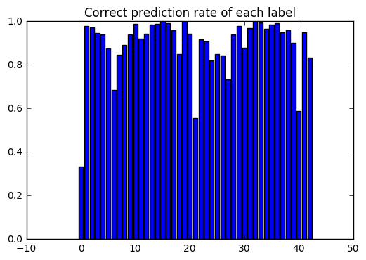

```
{0: 0.3333333333333333, 1: 0.9777777777777777, 2: 0.9733333333333334, 3: 0.9466666666666667, 4: 0.9409090909090909, 5: 0.8746031746031746, 6: 0.6866666666666666, 7: 0.8466666666666667, 8: 0.8933333333333333, 9: 0.9395833333333333, 10: 0.9893939393939394, 11: 0.9214285714285714, 12: 0.942028985507246…
```

```python
Correct_rate = {}
for i in range(43):
    Correct_rate[i] = list(output[i]).count(True)/len(list(output[i]))*1.0

plt.bar(range(len(Correct_rate)), Correct_rate.values(), align='center')
plt.title("Correct prediction rate of each label")
plt.show()
print (Correct_rate)
```

It looks like 0-Speed limit (20km/h), 6-End of speed limit (80km/h), 21-Double curve and 40-Roundabout mandatory have the lowest accuracy.